# Embarassment Study Version 2 Analysis

#Load Data and calculating error rates on attention checks

```r
library(tidyverse)
#Load Data
Dat <- read.csv("EmbarrassmentEnvyVersion2.csv", TRUE)
Dat %>% filter(Gender == 1) %>% nrow()
```

```
## [1] 190
```

```r
#The percentage of people get wrong in Attention 1: correct answer coded value is 13.
nrow(Dat %>% filter( Attention.1!= 13 ))/nrow(Dat)
```

```
## [1] 0.09254499
```

```r
#The percentage of people get wrong in Attention 2( the math question) :correct answer coded value is 5.
nrow(Dat %>% filter( Attention2!= 5))/nrow(Dat)
```

```
## [1] 0.02570694
```

```r
#Percentage of people get wrong in both attention 1 and attention 2 :
nrow(Dat %>% filter( Attention2!= 5&Attention.1!= 13 ))/nrow(Dat)
```

```
## [1] 0.005141388
```

```r
#Percentage of people get wrong in attention 1 or attention 2 :
nrow(Dat %>% filter( Attention2!=5 |Attention.1!= 13 ))/nrow(Dat)
```

```
## [1] 0.1131105
```

The percentage of people get wrong in Attention 1: $9.25\%$ The percentage of people get wrong in Attention 2: $2.5\%$ Percentage of people get wrong in both attention 1 and attention 2:$0.5\%$ Percentage of people get wrong in attention 1 or attention 2:$11.3\%$ #Is failing attention 2 a predictor of failing attention 1?

```r
#Create binary variable for attention 2 error  and attention 1 error
Dat <- Dat %>% mutate(attention.1.error = if_else(Attention.1 == 13, "AC1 Correct" , "AC1 Incorrect"))
Dat <- Dat %>% mutate(attention.2.error = if_else(Attention2 == 5, "AC2 Correct" , "AC2 Incorrect"))
library(tidyverse)

# Visualize a graph to see the dependence of attention 2 and attention 1
#ggplot(Dat %>% filter(!is.na(attention.1.error) & !is.na(attention.2.error)) ) +
  #aes(x = attention.1.error, fill = attention.2.error) +
  #geom_bar() +
  #scale_fill_hue() +
  #theme_minimal()+
  #labs(x = "Attention 1 Check" , y = " Subject Count")+
  #scale_fill_discrete(name = "Attention 2 Check")

#Chi-Square table
Dat1<- Dat %>% filter(!is.na(attention.1.error)&!is.na(attention.2.error))

table(Dat1$attention.1.error,Dat1$attention.2.error)
```

```
##
##                 AC2 Correct AC2 Incorrect
##   AC1 Correct           341             8
##   AC1 Incorrect          34             2
```

```r
chisq.test(Dat$attention.1.error,Dat$attention.2.error)
```

```
##
##  Pearson's Chi-squared test with Yates' continuity correction
##
## data:  Dat$attention.1.error and Dat$attention.2.error
## X-squared = 0.38656, df = 1, p-value = 0.5341
```

The dependency of attention 1 check and attention 2 check is NOT significant X^2 tests: X^2 (**1**) = **0.39**, p=**0.5341**  
#Is Attention1/ Attention 2 a predictor of duration spent completing the study?

```r
#log transform the duration in seconds;

anova(lm(log(Duration..in.seconds.) ~ attention.1.error, data =  Dat))
```

|  | Df | Sum Sq | Mean Sq | F value | Pr(>F) |
| --- | --- | --- | --- | --- | --- |
| attention.1.error | 1 | 14.88211 | 14.8821091 | 36.4642 | 3.656685e-09 |
| Residuals | 386 | 157.53792 | 0.4081293 | NA | NA |

```r
anova(lm(log(Duration..in.seconds.) ~ attention.2.error, data =  Dat))
```

|  | Df | Sum Sq | Mean Sq | F value | Pr(>F) |
| --- | --- | --- | --- | --- | --- |
| attention.2.error | 1 | 0.6413427 | 0.6413427 | 1.452803 | 0.2288229 |
| Residuals | 383 | 169.0761087 | 0.4414520 | NA | NA |

Attention 1 significantly predict log( Study Duration in secs): F(**1**,**386**) = **36.46**, p < **0.01** Attention 2 does NOT significantly predict log( Study Duration in secs): F(**1**,**383**) = **1.45**, p = **0.23**

#Is sequential rating differences during dispositional envy scale a predictor of duration spent completing the study?

```r
#Calculate and mutate the column of sequential rating differences during dispositional envy scale:
Dat2<- Dat %>% filter(!is.na(Envy1)) %>% mutate(sequential_difference = abs(Envy1-Envy2)+abs(Envy2 -  Envy3)+abs(Envy3-Envy4)+abs(Envy4-Envy5)+abs(Envy5-Envy6)+abs(Envy6-Envy7)+abs(Envy7-Envy8))

#linear regression on sequential_difference predicting log transformed duration in seconds ;
anova(lm(log(Duration..in.seconds.) ~ sequential_difference, data =  Dat2))
```

|  | Df | Sum Sq | Mean Sq | F value | Pr(>F) |
| --- | --- | --- | --- | --- | --- |
| sequential_difference | 1 | 1.744028 | 1.7440275 | 3.944284 | 0.0477378 |
| Residuals | 386 | 170.675998 | 0.4421658 | NA | NA |

```r
#liner regression of attention 1 error predicting sequential difference.
anova(lm(sequential_difference ~attention.1.error, data = Dat2))
```

|  | Df | Sum Sq | Mean Sq | F value | Pr(>F) |
| --- | --- | --- | --- | --- | --- |
| attention.1.error | 1 | 362.6117 | 362.61174 | 9.511018 | 0.002189358 |
| Residuals | 386 | 14716.4192 | 38.12544 | NA | NA |

Sequential difference significantly predicts log transformed duration in seconds:F(**1**,**386**) = **3.94**, p = **0.048** Sequential difference significantly predicts attention 1 error :F(**1**,**386**) = **9.51**, p < **0.01** #Data wrangling

```r
#Delete the participants' data that fail the attention checks
Dat_attention_check_passed <- Dat %>% filter(Attention.1 == 13 & Attention2 == 5)
type_gender_know <- Dat_attention_check_passed %>% select(Gender, ResponseId, starts_with(c("Body", "Judgment")))

#type_gender_know <-
  #type_gender_know %>%
 # rename(Body.Naked_1 = Body.Naked._1, Body.Naked_2 = Body.Naked._2)
test <- type_gender_know %>%
  select(Gender, Body.Bowel_1, Body.Bowel_2)

test %>% pivot_longer(cols=c(Body.Bowel_1, Body.Bowel_2), names_to = "doctor_type", values_to = "scores", names_prefix="Body.Bowel_")
```

| Gender | doctor_type | scores |
| --- | --- | --- |
| 2 | 1 | 5 |
| 2 | 2 | 4 |
| 2 | 1 | 6 |
| 2 | 2 | 5 |
| 2 | 1 | 3 |
| 2 | 2 | 2 |
| 2 | 1 | 4 |
| 2 | 2 | 4 |
| 1 | 1 | 4 |
| 1 | 2 | 3 |

[output cut: 672 more lines]

```r
repeated_ready <-
type_gender_know %>%
  pivot_longer(cols = starts_with(c("Judgment", "Body")),
                 values_to = "scores",
                 names_to = (c("Type", "Sub", "Doctor")),
               names_pattern = c("(.*)\\.(.*)_(.)"))
```

#Plots

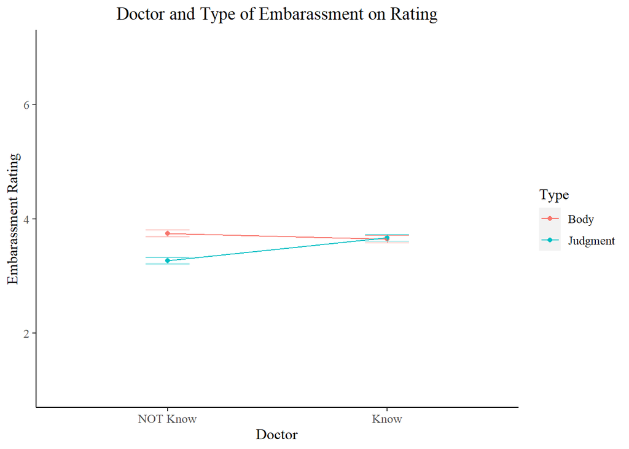

```r
# Doctor and Type or Embarrassment on Rating

repeated_ready$Doctor <- as.factor(repeated_ready$Doctor)
repeated_ready$Doctor <- recode_factor(repeated_ready$Doctor, "1" = "NOT Know","2" = "Know")

repeated_ready%>%
  ggplot() +
  aes(x = Doctor, color = Type, group = Type, y = scores) +
  stat_summary(fun.y = mean, geom = "point") +
  stat_summary(fun.y = mean, geom = "line")+
  labs(y = "Embarassment Rating")+
  theme (plot.title = element_text(hjust = 0.5), text = element_text(family = "serif", size = 12),
         panel.grid.major = element_blank(),
         panel.grid.minor = element_blank(),
         panel.background = element_blank(),
         axis.line = element_line(colour = "black"))+
          ggtitle("Doctor and Type of Embarassment on Rating")+
          stat_summary(fun.data = "mean_se",geom = "errorbar", size = 0.05,width = 0.2)+
           scale_y_continuous(limits = c(1, 7))
```

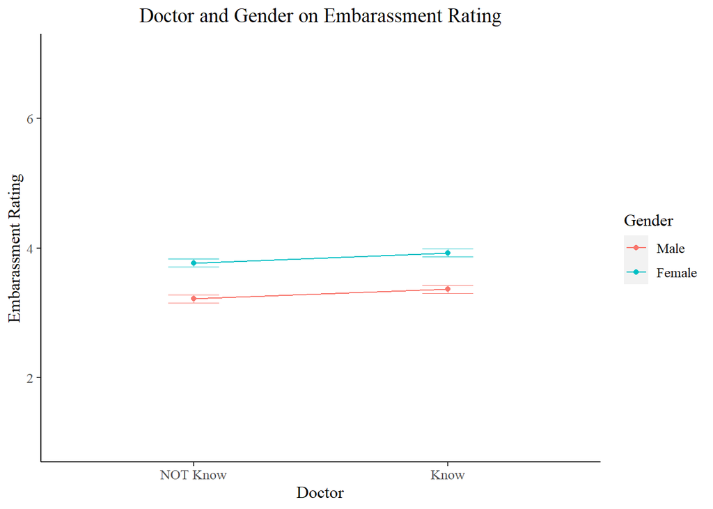

```r
#Doctor and Gender on Embarassment Rating

repeated_ready$Gender <- as.factor(repeated_ready$Gender)
repeated_ready$Gender <- recode_factor(repeated_ready$Gender, "1" = "Male","2" = "Female")

 repeated_ready %>% ggplot() +
  aes(x = Doctor, color = Gender, group = Gender, y = scores) +
  stat_summary(fun.y = mean, geom = "point") +
  stat_summary(fun.y = mean, geom = "line")+
  labs(y = "Embarassment Rating")+
  theme (plot.title = element_text(hjust = 0.5), text = element_text(family = "serif", size = 12),
         panel.grid.major = element_blank(),
         panel.grid.minor = element_blank(),
         panel.background = element_blank(),
         axis.line = element_line(colour = "black"))+
   stat_summary(fun.data = "mean_se",geom = "errorbar", size = 0.05,width = 0.2)+
  ggtitle("Doctor and Gender on Embarassment Rating")+
    scale_y_continuous(limits = c(1, 7))
```

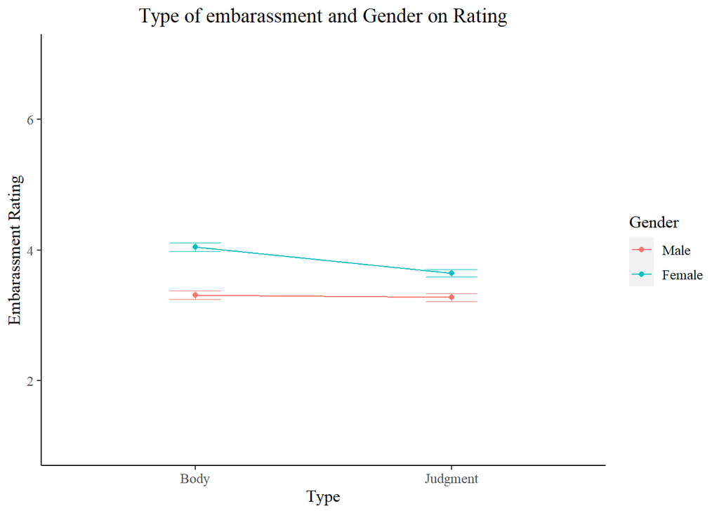

```r
#Embarassment Type and Gender on Embarassment Rating

 repeated_ready %>% ggplot() +
   aes(x = Type, color = Gender, group = Gender, y = scores) +
   stat_summary(fun.y = mean, geom = "point") +
   stat_summary(fun.y = mean, geom = "line")+
   labs(y = "Embarassment Rating")+
   theme (plot.title = element_text(hjust = 0.5), text = element_text(family = "serif", size = 12),
          panel.grid.major = element_blank(),
          panel.grid.minor = element_blank(),
          panel.background = element_blank(),
          axis.line = element_line(colour = "black"))+
   stat_summary(fun.data = "mean_se",geom = "errorbar", size = 0.05,width = 0.2)+
   ggtitle("Type of embarassment and Gender on Rating")+
   scale_y_continuous(limits = c(1, 7))
```

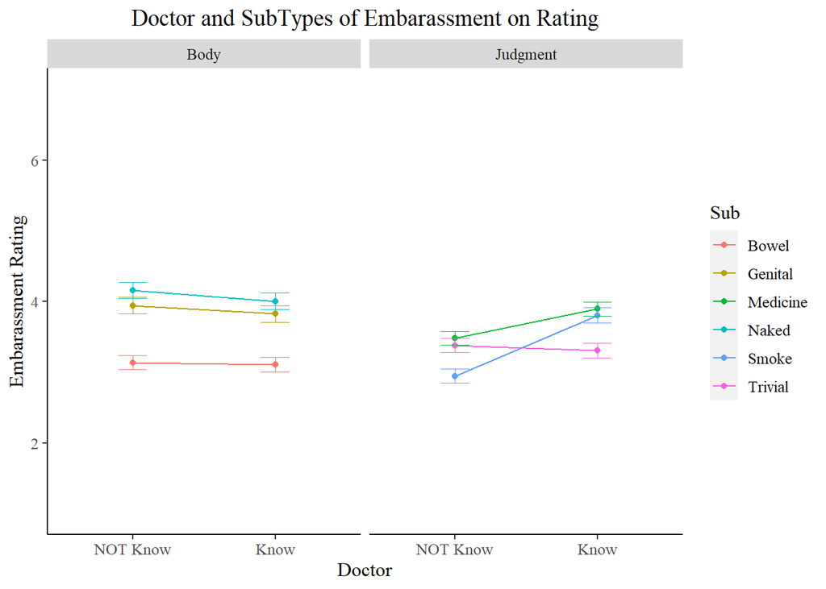

```r
# Doctor and SubTypes of Embarassment on Rating

repeated_ready%>%
  ggplot() +
  aes(x = Doctor, color = Sub, group = Sub, y = scores) +
  stat_summary(fun.y = mean, geom = "point") +
  stat_summary(fun.y = mean, geom = "line")+
  labs(y = "Embarassment Rating")+
  theme (plot.title = element_text(hjust = 0.5), text = element_text(family = "serif", size = 12),
         panel.grid.major = element_blank(),
         panel.grid.minor = element_blank(),
         panel.background = element_blank(),
         axis.line = element_line(colour = "black"))+
  ggtitle("Doctor and SubTypes of Embarassment on Rating")+
  stat_summary(fun.data = "mean_se",geom = "errorbar", size = 0.05,width = 0.2)+
   facet_wrap(.~Type)+
   scale_y_continuous(limits = c(1, 7))
```

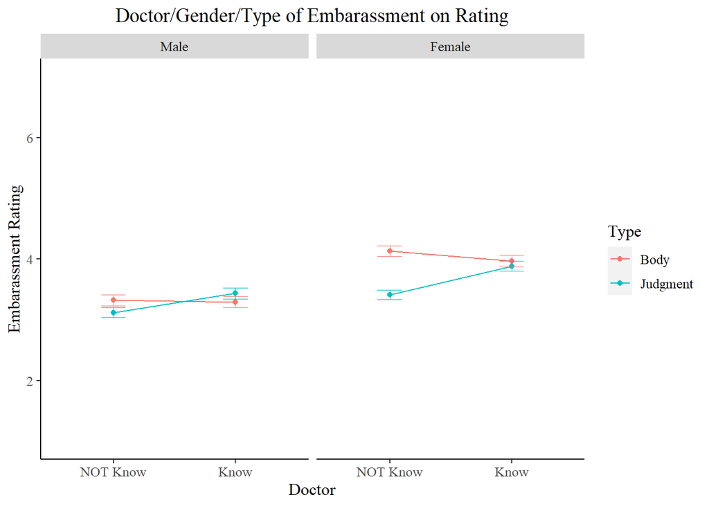

```r
 repeated_ready%>%
  ggplot() +
  aes(x = Doctor, color = Type, group = Type, y = scores) +
  stat_summary(fun.y = mean, geom = "point") +
  stat_summary(fun.y = mean, geom = "line")+
  labs(y = "Embarassment Rating")+
  theme (plot.title = element_text(hjust = 0.5), text = element_text(family = "serif", size = 12),
         panel.grid.major = element_blank(),
         panel.grid.minor = element_blank(),
         panel.background = element_blank(),
         axis.line = element_line(colour = "black"))+
          ggtitle("Doctor/Gender/Type of Embarassment on Rating")+
          stat_summary(fun.data = "mean_se",geom = "errorbar", size = 0.05,width = 0.2)+
          facet_wrap(.~ Gender)+scale_y_continuous(limits = c(1, 7))
```

#Repeated Measure Full Model

```r
model1<- aov(scores ~ Gender*Type*Doctor+Error(ResponseId/(Type*Doctor)), data = repeated_ready)
 summary(model1)
```

```
##
## Error: ResponseId
##            Df Sum Sq Mean Sq F value   Pr(>F)
## Gender      1    316  315.57   16.62 5.68e-05 ***
## Residuals 339   6435   18.98
## ---
## Signif. codes:  0 '***' 0.001 '**' 0.01 '*' 0.05 '.' 0.1 ' ' 1
##
## Error: ResponseId:Type
##              Df Sum Sq Mean Sq F value  Pr(>F)
## Type          1   52.6   52.61   7.148 0.00787 **
## Gender:Type   1   35.2   35.17   4.777 0.02952 *
## Residuals   339 2495.4    7.36
## ---
## Signif. codes:  0 '***' 0.001 '**' 0.01 '*' 0.05 '.' 0.1 ' ' 1
##
## Error: ResponseId:Doctor
##                Df Sum Sq Mean Sq F value  Pr(>F)
## Doctor          1   22.9  22.883   7.666 0.00594 **
## Gender:Doctor   1    0.0   0.019   0.006 0.93690
## Residuals     339 1011.9   2.985
## ---
## Signif. codes:  0 '***' 0.001 '**' 0.01 '*' 0.05 '.' 0.1 ' ' 1
##
## Error: ResponseId:Type:Doctor
##                     Df Sum Sq Mean Sq F value Pr(>F)
## Type:Doctor          1   63.6   63.56  36.030  5e-09 ***
## Gender:Type:Doctor   1    5.6    5.55   3.149 0.0769 .
## Residuals          339  598.0    1.76
## ---
## Signif. codes:  0 '***' 0.001 '**' 0.01 '*' 0.05 '.' 0.1 ' ' 1
##
## Error: Within
##             Df Sum Sq Mean Sq F value Pr(>F)
## Residuals 2728   5295   1.941
```

Significant interaction of Doctor type and Embarrassment type: F(**1**,**339**) = **36.03**, p <**0.01**

Significant interaction of Gender and Embarrassment type: F(**1**,**339**) = **4.78**, p = **0.03**

Non-Significant interaction of Gender and Doctor type: F(**1**,**339**) = **0.006**, p = **0.94**

Non-Significant three-way interaction of Gender/Doctor type/Embarrassment type: F(**1**,**339**) = **3.15**, p = **0.077**

Significant Main effect of Doctor type: F(**1**,**339**) = **7.7**, p < **0.01**